# Random Variables

2025

## Core Concepts

- **Random Variable**: Process generating random outcomes.
- **Sample**: Outcomes from a random variable.
- **Descriptive Statistics**: Summary of a sample.
- **Inferential Statistics**: Educated guess about the random variable that generated a sample.

## Random Variable

- Process that generates random outcomes.
- Tied to a **population**.
- Has possible outcomes defined by a **sample space**.
- Is fundamentally defined by a **probability distribution**.

## Population

- A population is the entire set of things under study.
- E.g., all people in the world, all possible people in the world, all the neurons in the universe, the set of all possible action potential times relative to stimulus onset etc.

## Sample Space

- The set of all possible outcomes of a random variable.
- E.g., the set of all possible rolls of a die is \(\{1, 2, 3, 4, 5, 6\}\). It is **discrete** and **finite**.
- E.g., the set of all possible action potential times relative to stimulus onset spans the interval \((0, \infty)\). It is **continuous** and **infinite**.

## Probability Distribution

- Describes the likelihood of each outcome in the sample space.
- **Discrete**: A function that gives the probability of each outcome.
- **Continuous**: A function that gives the probability **density** for each outcome.

## Probability Distribution Recipe

- The sample space goes on the x-axis.
- The probability of each outcome goes on the y-axis.

## Probability Mass Function

- For a discrete random variable, the probability mass function (PMF) gives the probability of each outcome.
- **Example:** For a biased coin, the PMF is

  \[ P(X = x) = \begin{cases} 0.3 & \text{if } x = \text{heads} \\ 0.7 & \text{if } x = \text{tails} \end{cases} \]

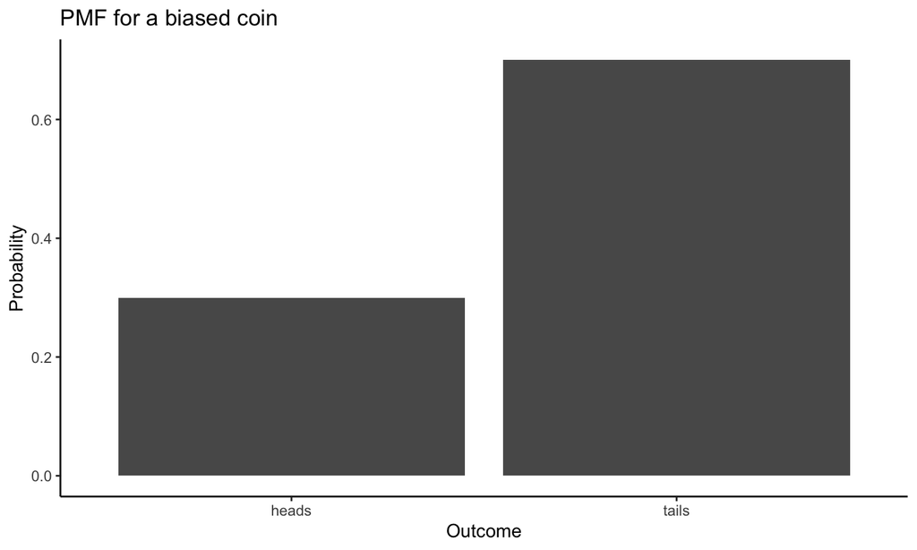

- **Example:** For a fair six-sided die, the PMF is \(P(X = x) = \frac{1}{6}\) for \(x \in \{1, 2, 3, 4, 5, 6\}\).

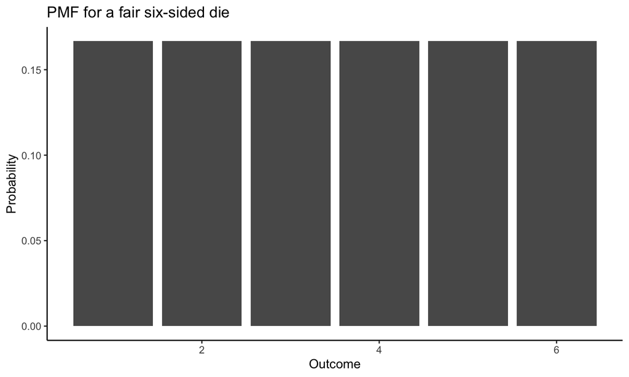

- **Example:** flipping a coin three times

| Toss 1 | Toss 2 | Toss 3 |
| --- | --- | --- |
| H | H | H |
| H | H | T |
| H | T | H |
| H | T | T |
| T | H | H |
| T | H | T |
| T | T | H |
| T | T | T |

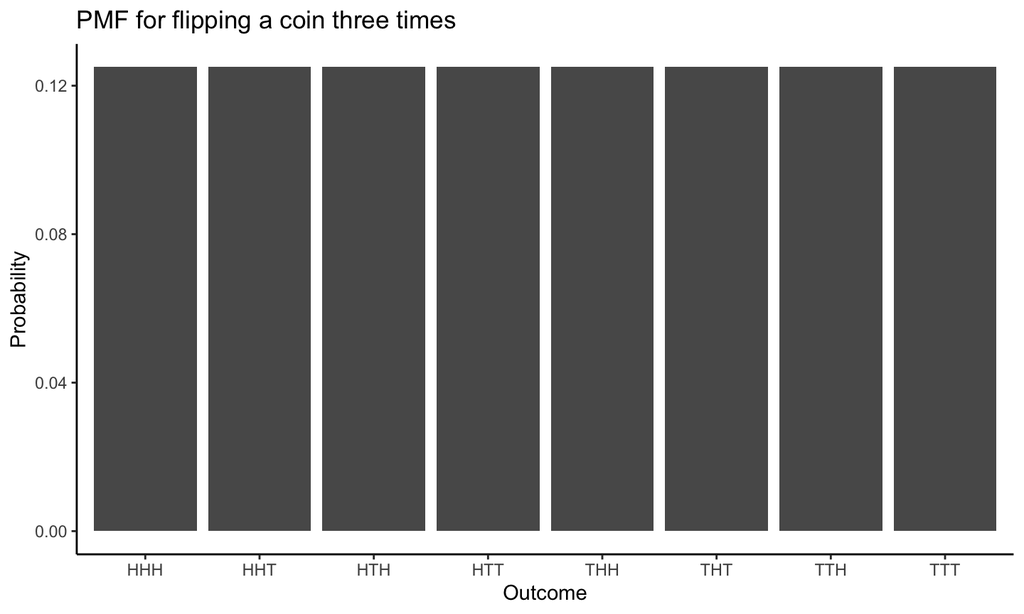

## Probability Density Function

- For a continuous random variable, the probability density function (PDF) gives the probability density for each outcome.
- **Example:** Distribution of heights in Australia
- Sample space: \((0, \infty)\)

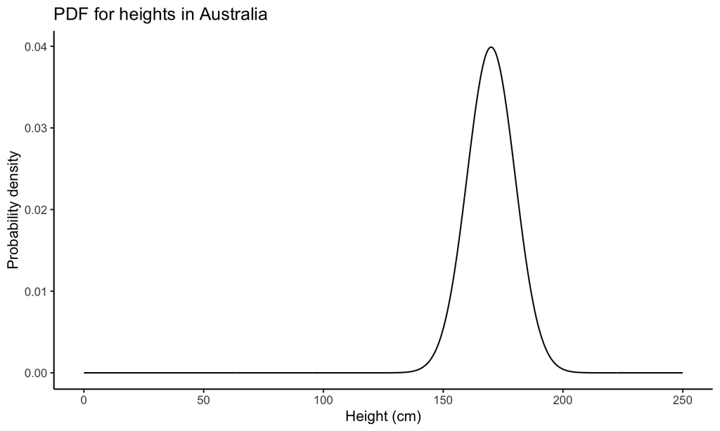

- **Example:** For a normal distribution with mean \(\mu = 0\) and standard deviation \(\sigma = 1\), the PDF is

  \[ f(x) = \frac{1}{\sqrt{2\pi}} e^{-\frac{x^2}{2}} \]

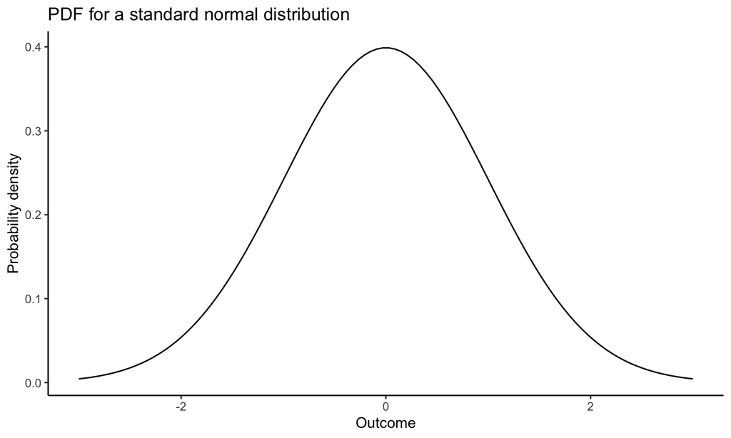

## Computing Probabilities from Distributions

- **Discrete case:** The probability of a particular outcome \(x\) is \(P(X = x)\).
- Read this from a probability table or plot.
- **Example:** Probability of 7 Heads in 10 Flips

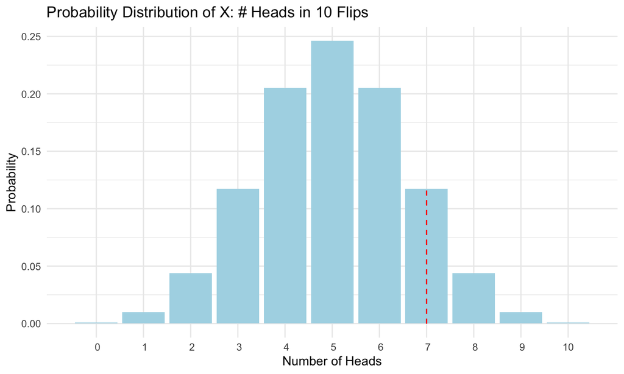

## Computing Probabilities from Distributions

- **Continuous case:** The probability of a range of values is the area under the curve.
- Example: The probability of reaction time between 400-600 ms.
- **Example:** Probability of Reaction Time between 400-600 ms

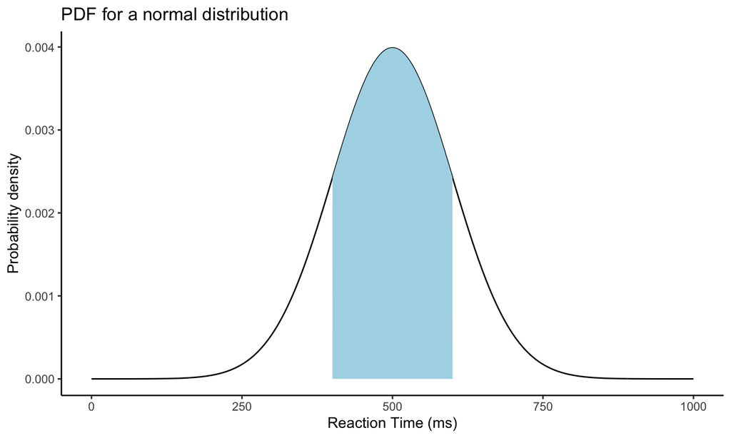

## Sampling from a Random Variable: Discrete

- Consider a biased coin with PMF \(P(X = x) = 0.3\) for heads and \(P(X = x) = 0.7\) for tails.
- Samples obtained from this distrubtion are random sequences of heads and tails.
- Because the coin is biased, we expect to see more tails than heads.

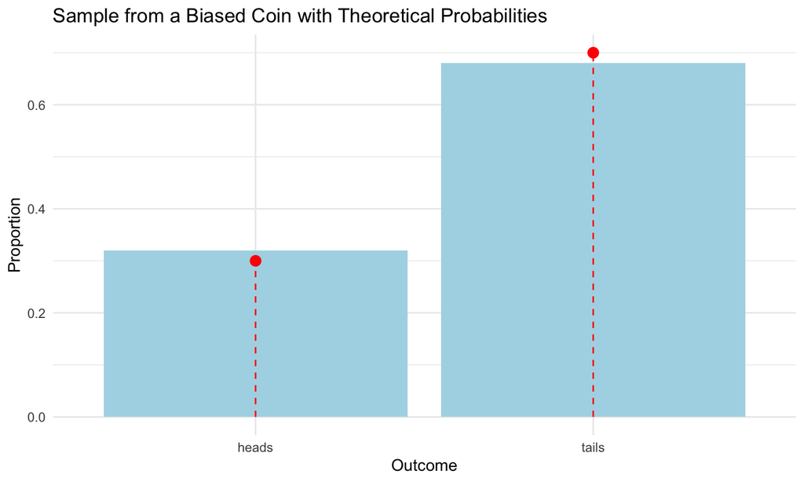

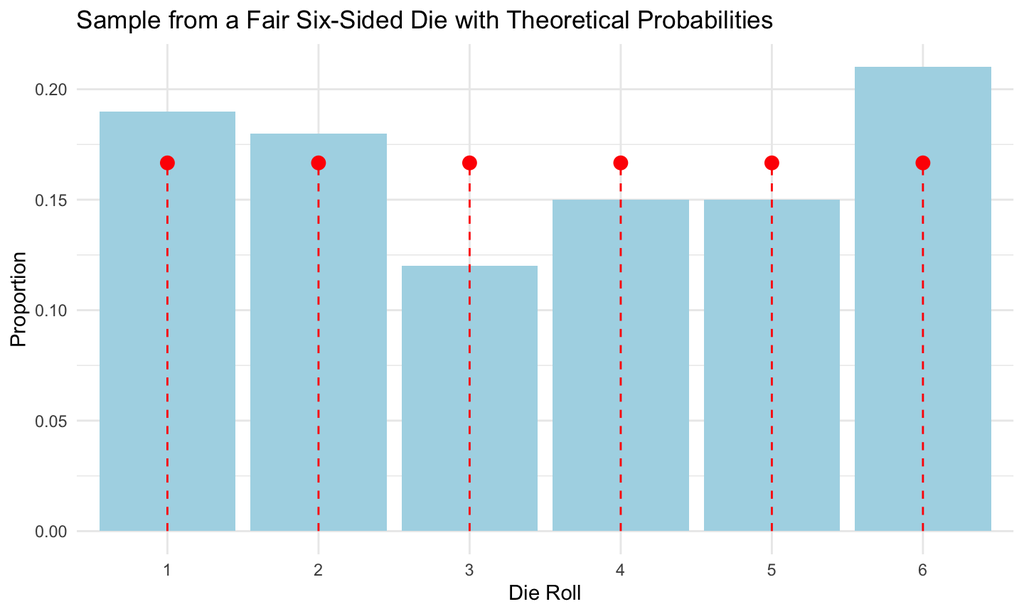

## Sample from a Random Variable: Continuous

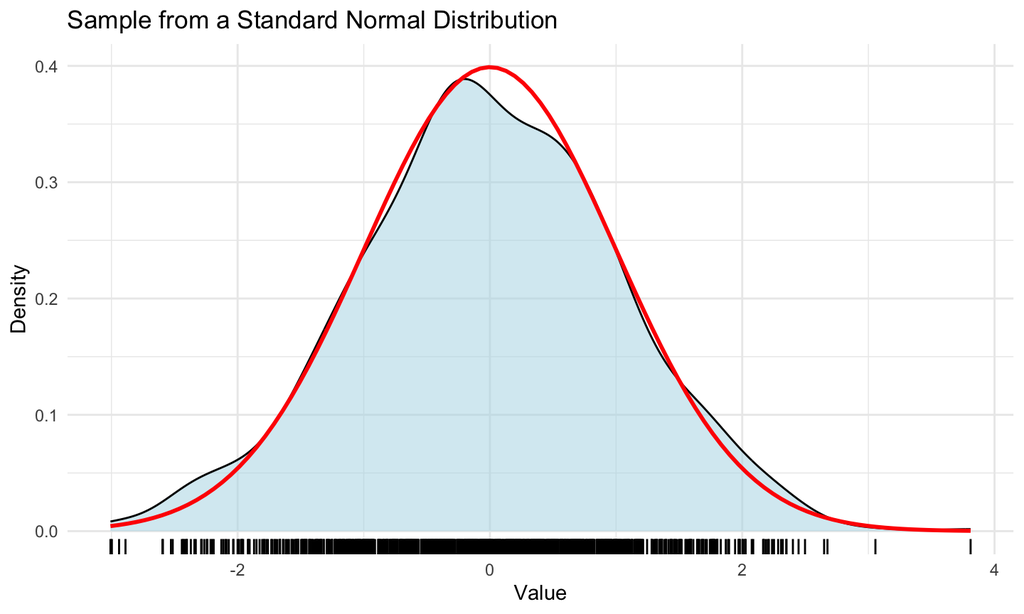

## Quiz Question 1

A six-sided die is rolled, and the outcome is recorded. Which of the followin best describes the probability distribution of this random variable?

**A.** A probability density function (PDF) because the outcome is continuous.

**B.** A probability mass function (PMF) because the outcome is discrete.

**C.** A cumulative distribution function (CDF) because the outcome is deterministic.

**D.** A uniform density function because the outcome is continuous.

**Click to see the solution**

**Correct Answer:** **B.** A probability mass function (PMF) because the outcome is discrete.

## Quiz Question 2

A researcher is studying the distribution of human reaction times in milliseconds (ms) to a visual stimulus. The reaction time is measured as a continuous variable. Which of the following best describes the probability distribution used to model this data?

**A.** A probability mass function (PMF) because reaction time is discrete.

**B.** A probability density function (PDF) because reaction time is continuous.

**C.** A cumulative distribution function (CDF) because reaction time is always increasing.

**D.** A binomial distribution because reaction time is categorical.

**Click to see the solution**

**Correct Answer:** **B.** A probability density function (PDF) because reaction time is continuous.

## Quiz Question 3

You are rolling a fair six-sided die and want to compute the probability of rolling a number greater than 4.

Which of the following correctly calculates this probability?

**A.** \(P(X > 4) = \frac{1}{6} + \frac{1}{6} = \frac{2}{6} = \frac{1}{3}\)

**B.** \(P(X > 4) = 1 - P(X \leq 4) = 1 - \frac{4}{6} = \frac{1}{3}\)

**C.** \(P(X > 4) = P(X = 5) \times P(X = 6) = \frac{1}{6} \times \frac{1}{6} = \frac{1}{36}\)

**D.** \(P(X > 4) = P(X = 4) + P(X = 5) + P(X = 6) = \frac{3}{6} = \frac{1}{2}\)

**Click to see the solution**

**Correct Answer:** **A and B**

- The valid outcomes for \(X > 4\) are rolling a 5 or a 6.
- Since the die is fair, \(P(X = 5) = \frac{1}{6}\) and \(P(X = 6) = \frac{1}{6}\).
- Therefore,

  \[ P(X > 4) = P(X = 5) + P(X = 6) = \frac{1}{6} + \frac{1}{6} = \frac{2}{6} = \frac{1}{3} \]
- Alternatively, using the complement rule:

  \[ P(X > 4) = 1 - P(X \leq 4) = 1 - \frac{4}{6} = \frac{1}{3} \]

## Quiz question 4

A probability density function (PDF) is defined as follows:

- \(f(x) = 0.1\) for \(0 \leq x \leq 3\)
- \(f(x) = 0.2\) for \(3 < x \leq 5\)
- \(f(x) = 0\) otherwise
- See next slide for the PDF plot.

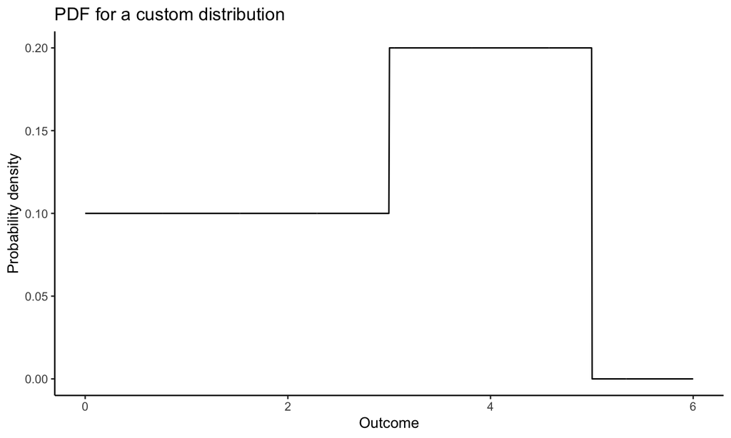

- See next slide for quiz question.

What is the probability that a randomly drawn value from this distribution falls between \(x=2\) and \(x=5\)?

**A.** \(0.1 \times (3-2) + 0.2 \times (5-3) = 0.1 + 0.4 = 0.5\)

**B.** \(0.1 \times (5-2) = 0.3\)

**C.** \(0.2 \times (5-2) = 0.6\)

**D.** \(0.1 \times (3-2) + 0.2 \times (5-3) + 0.1 \times (5-4) = 0.1 + 0.4 + 0.1 = 0.6\)

- See next slide for solution.

**Click to see the solution**

**Correct Answer:** **A**

The probability is the area under the PDF curve from \(x=2\) to \(x=5\). Since the PDF consists of two rectangular sections, we compute the total area using basic geometry:

1. From \(x=2\) to \(x=3\), the height is \(0.1\), and the width is \((3-2)=1\):  
   \[\text{Area} = 0.1 \times 1 = 0.1\]
2. From \(x=3\) to \(x=5\), the height is \(0.2\), and the width is \((5-3)=2\):  
   \[\text{Area} = 0.2 \times 2 = 0.4\]
3. Total probability:  
   \[P(2 \leq X \leq 5) = 0.1 + 0.4 = 0.5\]